# Loading Data Into R

ASI: Introduction to R

Author

Affiliation

Dr Stevie Pederson

Black Ochre Data Labs  
Telethon Kids Institute

Published

November 21, 2023

# Loading Data Into R

## Data In R

- Working with data in R is **very different** to Excel
- Can have complicated structures or be very simple (e.g. `x <- 1:5`)
- Spreadsheet-like data is very common
  - The `R` equivalent is known as a `data.frame`
  - Has many variants, e.g. `tbl_df` or `tibble` (SQL-inspired)
  - We’ll mainly use the `tibble` variant today  
    $\implies$ is a `data.frame` with pretty bows & ribbons

. . .

- We import the data as an `R` object
  - All analysis is performed on the `R` object
  - **Almost never** modify the source file

## Importing Data

- *Cell formatting will be ignored by R*
- *Plots will also be ignored*
- Blank rows are not fatal, just annoying
- Mixtures of numbers and text in a column
  - `data.frame`s are structured with vectors as columns
- Deleted cells are sometimes imported as blank rows/columns
- Comma-separated or tab-separated files are favoured for `R`
  - i.e. plain text, or *just the data*

## Other Common Excel Issues

1. Excel thinks everything is a date:
   - Septin genes are now officially named *SEPTIN2* etc (not *SEPT2*)
   - Fractions are also not dates…
2. Excel will remove leading zeroes (e.g. phone numbers, catalog ids)
3. No record of any steps we’ve performed by clicking on something

. . .

- These are very common sources of broken data $\implies$ may need fixing
- There are large numbers of publications with dates for gene names or results

Mention my former collaborator who would often have completely different results in the ones I’d send him - To sort by p-value, he’d select the p-value column & sort (just that column) - There was no record of this. Only discovered by sitting down with him

## Preparation

1. `File` > `New File` > `R Script` (Or `Ctrl+Shift+N`)
2. Save as `DataImport.R`

## Preparation

Then get the data for this exercise.

1. Download the file `data.zip` from the workshop homepage
2. Place in your directory `R_Training`
3. Extract to create a folder named `data`
4. This should contain all of today’s files
5. Navigate to the `data` directory using the `Files` pane

(You should see `pigs.csv` in there)

(Make sure people haven’t accidentally created `data/data`)

# Import Using the GUI

## Importing Data

1. Preview the file `pigs.csv` by clicking on it (`View File`)
   - Try in Excel if you prefer, but DO NOT save anything from Excel

. . .

- The data measures tooth (i.e. odontoblast) length in guinea pigs
  - Using 3 dose levels of Vitamin C (“Low”, “Med”, “High”)
- Vitamin C was given in drinking water or using orange juice
  - “OJ” or “VC”

## Importing Data

- This type of data is very easy to manage in `R`
  - Plain text with comma delimiters
  - Simple column structure with column names
  - No blank rows at the top or separating sub-tables
  - No blank columns
  - No rownames

## Using the GUI To Load Data

Click on the `pigs.csv` and choose `Import Dataset` then **stop**!

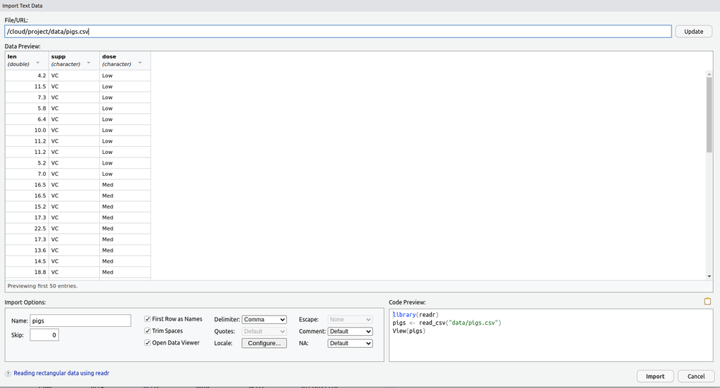

(Click `Update` if you don’t see this)

## The Preview Window

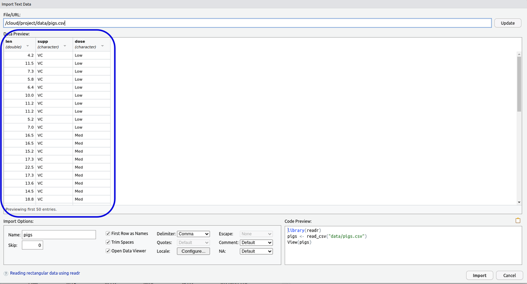

We have a preview of the data

- This is another preview of the data before we import it
- There are 3 columns: `len`, `supp` and `dose`
  - `len` is a double (numeric)
  - The other two are character columns

## The Preview Window

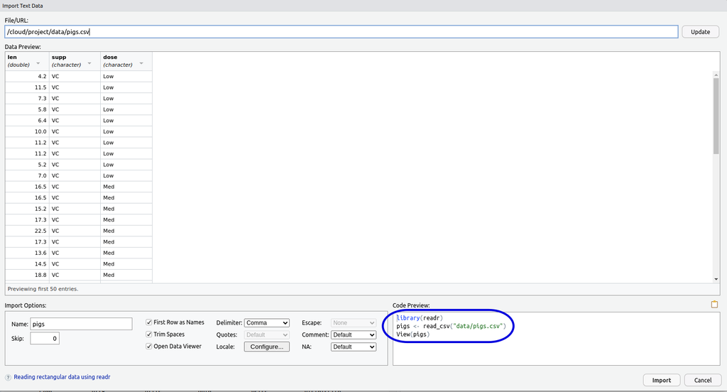

We also have a preview of the code we’re about to execute

## The Preview Window

1. Select and copy all the code in the `Code Preview` Box
   - We’ll paste this somewhere in a minute…

. . .

2. Click `Import`

. . .

3. Magic happens!!!
   - Ignore the red/blue text. This is just ‘helpful’ information

. . .

*Now paste the copied code at the top of your script*

## What just happened?

The code we copied has 3 lines:

```r
library(readr)
pigs <- read_csv("data/pigs.csv")
View(pigs)
```

- Loads the package `readr` using `library(readr)`
  - Packages are collections (i.e. libraries) of related functions
  - All `readr` functions are about importing data
- `readr` contains the function `read_csv()`
- `read_csv()` tells R what to do with a csv file

## What just happened?

The code we copied has 3 lines:

```r
library(readr)
pigs <- read_csv("data/pigs.csv")
View(pigs)
```

- This line actually loads the data into your `R Environment`
- It created an object named `pigs` by using the file name (pigs.csv)
- Can change this name if we wish

## What just happened?

The code we copied has 3 lines:

```r
library(readr)
pigs <- read_csv("data/pigs.csv")
View(pigs)
```

- Opens a preview in a familiar `Excel-like` format
  - I personally **never** use this

Close the preview by clicking the cross

## What just happened?

- We have just loaded data using the default settings of `read_csv()`
- The object `pigs` is now in our `R Environment`
  - The original file remains on our HDD **without modification**!!!
- The code is saved in our script  
  $\implies$ **we don’t need the GUI for this operation again!**

## Let’s Demonstrate

1. In the `Environment Tab` click the broom icon ()
   - This will delete everything from your `R Environment`
   - It won’t unload the packages

. . .

2. Select the code we’ve just pasted and send it to the console
   - Reloading the packages won’t hurt

. . .

3. Check the `Environment Tab` again and `pigs` is back

. . .

You can delete the line `View(pigs)`

Realistically we only need to preview it the first time. Having that preview open every time actually ends up being really annoying

# Data Frame Objects

## Data Frame Objects

- The object `pigs` is known as a `data.frame`
  - Very similar to an SQL table
- `R` equivalent to a spreadsheet
  - Missing values (blank cells) are usually filled with `NA`
  - **Must** have column names $\implies$ row names becoming less common

## Data Frame Objects

Instead of `View()` $\implies$ preview by typing the object name

```r
pigs
```

```
# A tibble: 60 × 3
     len supp  dose
   <dbl> <chr> <chr>
 1   4.2 VC    Low
 2  11.5 VC    Low
 3   7.3 VC    Low
 4   5.8 VC    Low
 5   6.4 VC    Low
 6  10   VC    Low
 7  11.2 VC    Low
 8  11.2 VC    Low
 9   5.2 VC    Low
10   7   VC    Low
# ℹ 50 more rows
```

Gives a preview up to 10 lines with:

- The object type: `A tibble`
- The full dimensions: `60 X 3`
- Column names: `len`, `supp`, `dose`
- Data types: `<dbl>`, `<chr>`, `<chr>`

I personally find this more informative than `View()`

## Data Frame Objects

- `data.frame` objects can be subset using square brackets `[row, col]`

```r
pigs[1:3, ]
```

```
# A tibble: 3 × 3
    len supp  dose
  <dbl> <chr> <chr>
1   4.2 VC    Low
2  11.5 VC    Low
3   7.3 VC    Low
```

```r
pigs[, "len"]
```

```
# A tibble: 60 × 1
     len
   <dbl>
 1   4.2
 2  11.5
 3   7.3
 4   5.8
 5   6.4
 6  10
 7  11.2
 8  11.2
 9   5.2
10   7
# ℹ 50 more rows
```

## Data Frame Objects

- Entire columns can also be selected using `$`  
  $\implies$ doesn’t return a `data.frame`

```r
pigs$len
```

```
 [1]  4.2 11.5  7.3  5.8  6.4 10.0 11.2 11.2  5.2  7.0 16.5 16.5 15.2 17.3 22.5
[16] 17.3 13.6 14.5 18.8 15.5 23.6 18.5 33.9 25.5 26.4 32.5 26.7 21.5 23.3 29.5
[31] 15.2 21.5 17.6  9.7 14.5 10.0  8.2  9.4 16.5  9.7 19.7 23.3 23.6 26.4 20.0
[46] 25.2 25.8 21.2 14.5 27.3 25.5 26.4 22.4 24.5 24.8 30.9 26.4 27.3 29.4 23.0
```

- Each column is a *vector*
  - Exactly like a spreadsheet column
- Vectors **only contain one data type**
  - `logical`, `integer`, `numeric` (i.e. doubles), `character`
  - `len` values are all `numeric` (or `dbl`)
- All types are given when printing a `tibble`

## Tibble Objects

- `readr` uses a variant called a `tbl_df` or `tbl` (pronounced tibble)
  - A `data.frame` with nice bonus features (e.g. prints a summary only)
  - Similar to a SQL table
  - Can *only have row numbers for row names*
  - Is a foundational structure in the `tidyverse`

## The Tidyverse

- The `tidyverse` is a collection of *thematically-linked* packages
  - Produced by developers from RStudio/Posit
  - Often referred to as *tidy*-programming or similar
- Calling `library(tidyverse)` loads **all** of these packages
  - $>$ 30 convenient packages in one line
  - `readr` is one of these $\implies$ usually just load the tidyverse

. . .

```r
library(tidyverse)
tidyverse_packages()
```

```
 [1] "broom"         "conflicted"    "cli"           "dbplyr"
 [5] "dplyr"         "dtplyr"        "forcats"       "ggplot2"
 [9] "googledrive"   "googlesheets4" "haven"         "hms"
[13] "httr"          "jsonlite"      "lubridate"     "magrittr"
[17] "modelr"        "pillar"        "purrr"         "ragg"
[21] "readr"         "readxl"        "reprex"        "rlang"
[25] "rstudioapi"    "rvest"         "stringr"       "tibble"
[29] "tidyr"         "xml2"          "tidyverse"
```

## Tibble Objects

**Replace `library(readr)` with `library(tidyverse)`** and execute

. . .

- Some additional ways to inspect data frames are:

```r
head(pigs)
glimpse(pigs)
```

- `glimpse` is loaded with `library(tidyverse)` (not part of `readr`)

**What were the differences between each method?**

# Functions

## Functions in `R`

```r
head(pigs)
glimpse(pigs)
```

- Here we have called the functions 1) `head()` and 2) `glimpse()`
  - They were both executed on the object `pigs`

. . .

- Call the help page for `head()`

```r
?head
```

(if you get multiple options, choose the one from `utils`)

## Functions in `R`

- The key place to look at is

```r
head(x, ...)
## Default S3 method:
head(x, n = 6L, ...)
```

- there are two arguments to `head()` $\implies$ `x` and `n`
  - `x` has no default value $\implies$ we need to provide something
  - `n = 6L` means `n` has a default value of 6 (L $\implies$ `integer`)

Execute `head()` to show the error!!!

## Functions in `R`

Lower down the page you’ll see

**Arguments**

`x` an object  
`n` an integer vector of length up to dim(x) (or 1, for non-dimensioned objects). *Blah, blah, blah…*

. . .

- Some of the rest is technical detail (sometimes *very helpful*)

## Function Arguments

- `head()` prints the *first part* of an object
- Useful for very large objects (e.g. if we had 1000 pigs)

. . .

- We can change the number of rows shown to us

```r
head(pigs, 4)
```

```
# A tibble: 4 × 3
    len supp  dose
  <dbl> <chr> <chr>
1   4.2 VC    Low
2  11.5 VC    Low
3   7.3 VC    Low
4   5.8 VC    Low
```

## Function Arguments

- Notice we didn’t provide these as named arguments
- If passing values in order $\implies$ no need

. . .

```r
head(pigs, 4)
```

```
# A tibble: 4 × 3
    len supp  dose
  <dbl> <chr> <chr>
1   4.2 VC    Low
2  11.5 VC    Low
3   7.3 VC    Low
4   5.8 VC    Low
```

```r
head(x = pigs, n = 4)
```

```
# A tibble: 4 × 3
    len supp  dose
  <dbl> <chr> <chr>
1   4.2 VC    Low
2  11.5 VC    Low
3   7.3 VC    Low
4   5.8 VC    Low
```

## Function Arguments

- If we name the arguments, we can pass *in any order we choose*

```r
head(n = 4, x = pigs)
```

```
# A tibble: 4 × 3
    len supp  dose
  <dbl> <chr> <chr>
1   4.2 VC    Low
2  11.5 VC    Low
3   7.3 VC    Low
4   5.8 VC    Low
```

## Function Arguments

- Check the help page for `glimpse()`
  - This is from the package `pillar`
- Try changing the `width` argument to see what happens

## Understanding `read_csv()`

- Earlier we called the `R` function `read_csv()`
- Check the help page

```r
?read_csv
```

- We have four functions shown but stick to `read_csv()`

## Understanding `read_csv()`

```r
read_csv(
  file,
  col_names = TRUE, col_types = NULL, col_select = NULL,
  id = NULL, locale = default_locale(),
  na = c("", "NA"), quoted_na = TRUE,
  quote = "\"", comment = "",
  trim_ws = TRUE,
  skip = 0, n_max = Inf,
  guess_max = min(1000, n_max),
  name_repair = "unique",
  num_threads = readr_threads(),
  progress = show_progress(),
  show_col_types = should_show_types(),
  skip_empty_rows = TRUE,
  lazy = should_read_lazy()
)
```

- This function has numerous *arguments* (`file`, `col_names` etc.)
- Most have default values given
  - All were defined *somewhere in the GUI*
  - The default assumes there are column names in the first row (`col_names = TRUE`)

## Understanding `read_csv()`

All `arguments` for the function were defined somewhere in the GUI.

1. Open the GUI Preview by clicking on the file again
2. Uncheck the `First Row as Names` checkbox

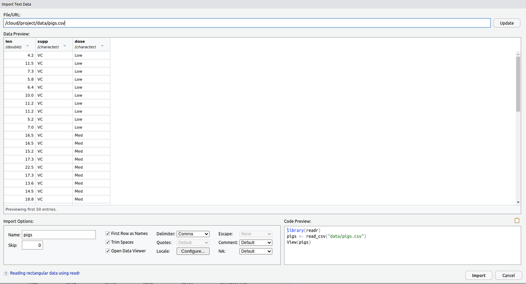

## Understanding `read_csv()`

All `arguments` for the function were defined somewhere in the GUI.

1. Open the GUI Preview by clicking on the file again
2. Uncheck the `First Row as Names` checkbox
   - *What happened to the code?*
   - *How did the columns change?*

. . .

Try clicking/unclicking a few more & try understand the consequences

# Closing Comments

## `read_csv()` Vs `read.csv()`

- `RStudio` now uses `read_csv()` from `readr` **by default**
- You will often see `read.csv()` in older scripts (from `utils`)
- The newer (`readr`) version is:
  - slightly faster
  - more user-friendly
  - creates fewer issues
  - gives informative messages

. . .

- Earlier functions in `utils` are `read.*()` (csv, delim etc.)
- `readr` has the functions `read_*()` (csv, tsv, delim etc.)
- I always use the newer ones

## Reading Help Pages: Bonus Slide

- The bottom three functions are simplified wrappers to `read_delim()`
- `read_csv()` calls `read_delim()` using `delim = ","`
- `read_csv2()` calls `read_delim()` using `delim = ";"`
- `read_tsv()` calls `read_delim()` using `delim = "\t"`

**What function would we call for *space-delimited* files?**

## Loading Excel Files

- The package `readxl` is for loading `.xls` and `xlsx` files.
- Not part of the core tidyverse but **very** compatible

```r
library(readxl)
```

. . .

- The main function is `read_excel()`

```r
?read_excel
```

## Loading Excel Files

- This file contains multiple sheets

```r
excel_sheets("data/RealTimeData.xlsx")
```

```
[1] "Sheet1" "Sheet2" "Sheet3"
```

I found this file after a random Google search for RT-PCR and Excel about 10 years ago. I didn’t keep track of who created it…

. . .

- Once again we can click on the file $\implies$ `Import Dataset`
  - `Sheet1` looks pretty simple
  - First column has no name

```r
pcr <- read_excel("data/RealTimeData.xlsx")
colnames(pcr)[1] <- "Sample"
```

. . .

- There are two pieces of data in the 1st column
  - We’ll learn how to manage this in the next session

. . .

- Have a look at the previews of Sheet2 and Sheet3
  - Everything here is surprisingly easy to wrangle